# Changes in Ozone Thickness (1927 - 2016)

Sherri McRae

2023-01-27

## Introduction

Measurements of ozone thickness taken yearly from 1927 to 2016 were analyzed to determine an appropriate trend model. A trend is defined as a change in mean over time. The trend models assessed were linear and quadratic regressions. The dataset contains 90 data points measured in Dobson Units.

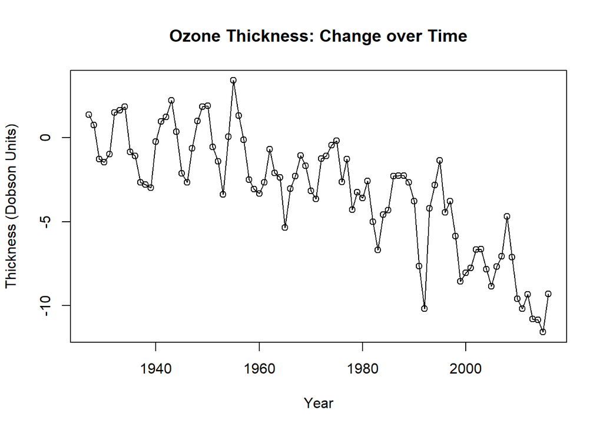

The data appears to exhibit a trend of decreasing ozone thickness over time. There is no seasonality as the data points represent yearly measurements. There does not appear to be any cyclic pattern, although autoregressive behaviour is apparent as successive data points are often close to previous point.

## Linear Regression Model:

In accordance with the principle of parsimony, the first model assessed was the simplest: the linear regression model. The linear regression trend line appears in red.

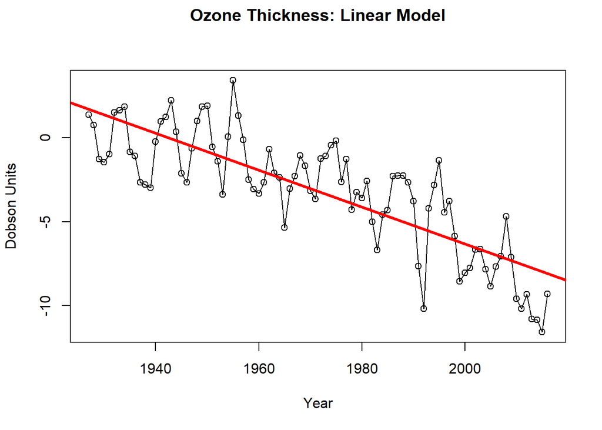

### Summary of Linear Model

```
##
## Call:
## lm(formula = ozone_ts ~ time(ozone_ts))
##
## Residuals:
##     Min      1Q  Median      3Q     Max
## -4.7165 -1.6687  0.0275  1.4726  4.7940
##
## Coefficients:
##                  Estimate Std. Error t value Pr(>|t|)
## (Intercept)    213.720155  16.257158   13.15   <2e-16 ***
## time(ozone_ts)  -0.110029   0.008245  -13.34   <2e-16 ***
## ---
## Signif. codes:  0 '***' 0.001 '**' 0.01 '*' 0.05 '.' 0.1 ' ' 1
##
## Residual standard error: 2.032 on 88 degrees of freedom
## Multiple R-squared:  0.6693, Adjusted R-squared:  0.6655
## F-statistic: 178.1 on 1 and 88 DF,  p-value: < 2.2e-16
```

The p-value value of this regression model is less than 0.01. The result is significant. The hypothesis that there is no correlation beteen the dataset and the trend line can be rejected. The R-squared value is 0.67 indicating a significant correlation with the trend line.

### Analysis of Residuals of the Linear Regression Model

A trend model that is reasonably correct should have residuals that behave like true stochastic components. That is, they will be normally distributed, random variables with mean of zero. In the following plot, the residuals, which have been standardized so that their mean is zero, are shown plotted against time. If the trend model is adequate, residuals will be scattered throughout the plot with no discernable trends.

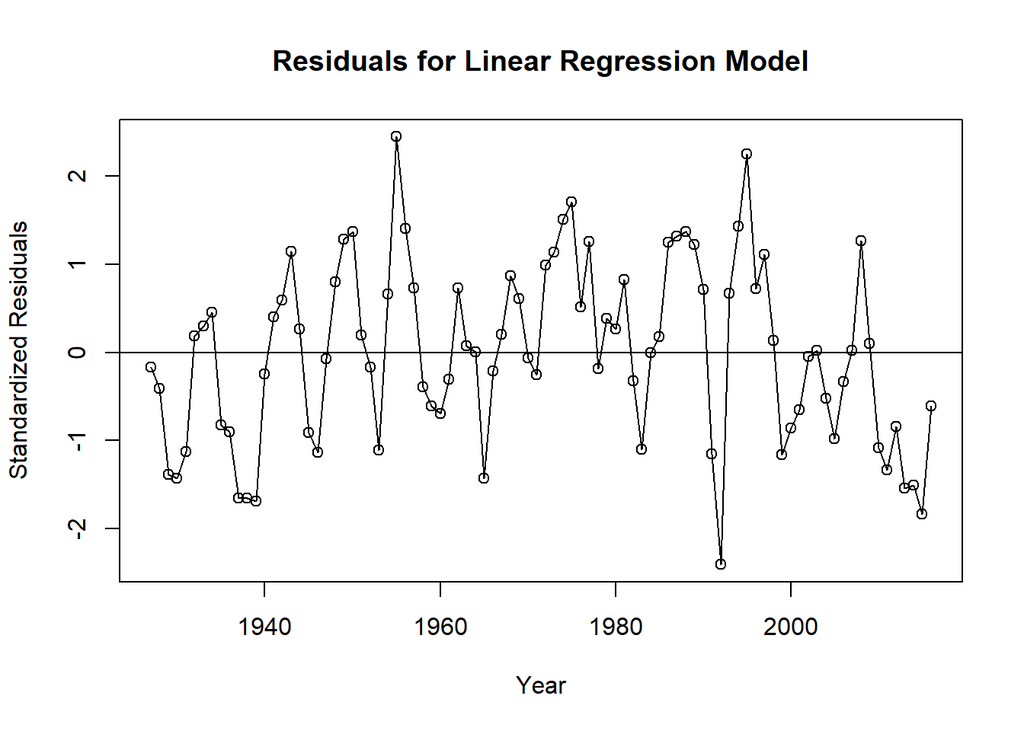

The residuals do not appear entirely random. There is clear autoregressive behaviour; clusters of two and three successive points. Also, there seems to be more points below the zero line at either end of the graph, creating the hint of a curve. These patterns indicate that a trend component of the data has not been removed.

The Shapiro-Wilk test is often used to determine if a distribution is normal. The null hypothesis of this test is that the sample is normally distributed.

```
##
##  Shapiro-Wilk normality test
##
## data:  res.model1
## W = 0.98733, p-value = 0.5372
```

As the p-value is 0.54, much greater than 0.05, the test fails to reject the null hypothesis. According to this test, the residuals of the linear regression model are normally distributed. Further analysis confirms that although the residuals approximate a normal distribution, they do not appear entirely random.

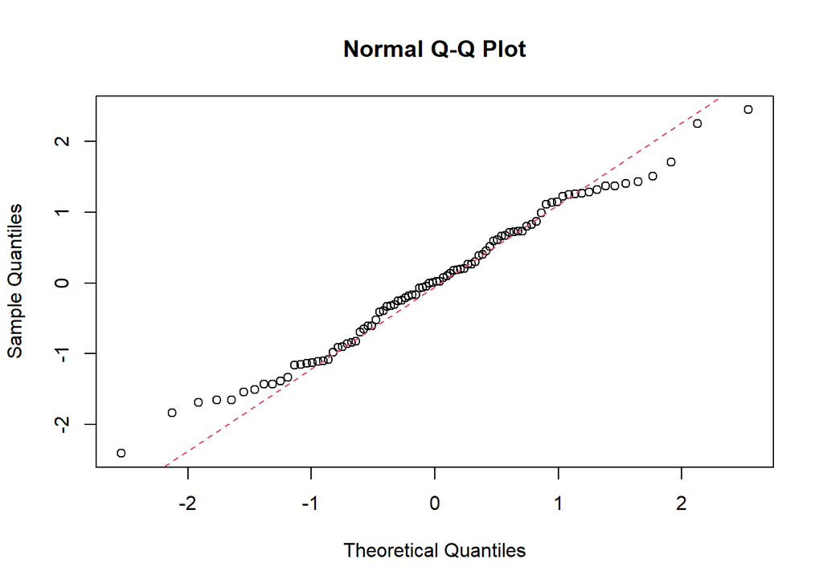

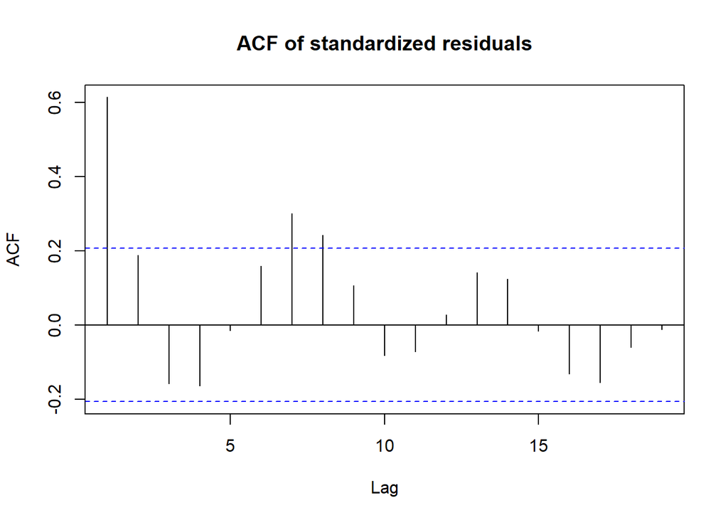

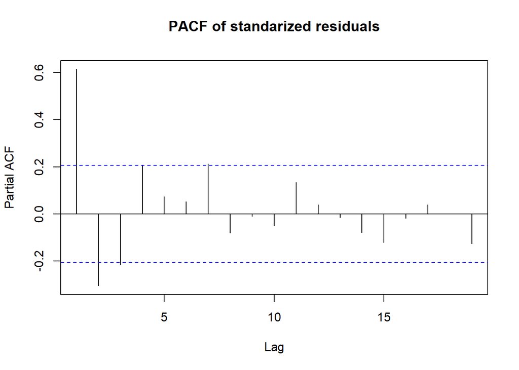

The QQ plot shows some departure from normality at either end of the reference line. As the sample size, 90, is much greater than 30, these deviations are not cause for too much concern. This plot confirms the results of the Shapiro-Wilk test.

Both the ACF and the PACF plots show correlation values higher than the confidence intervals. A completely random stochastic component would not show correlation at any lag. The residuals appear to contain more than just a stochastic component.

### Predictions Using the Linear Regression Model

```
##         fit       lwr       upr
## 1 -8.208590 -12.33732 -4.079864
## 2 -8.318619 -12.45033 -4.186902
## 3 -8.428648 -12.56342 -4.293878
## 4 -8.538677 -12.67656 -4.400792
## 5 -8.648706 -12.78977 -4.507643
```

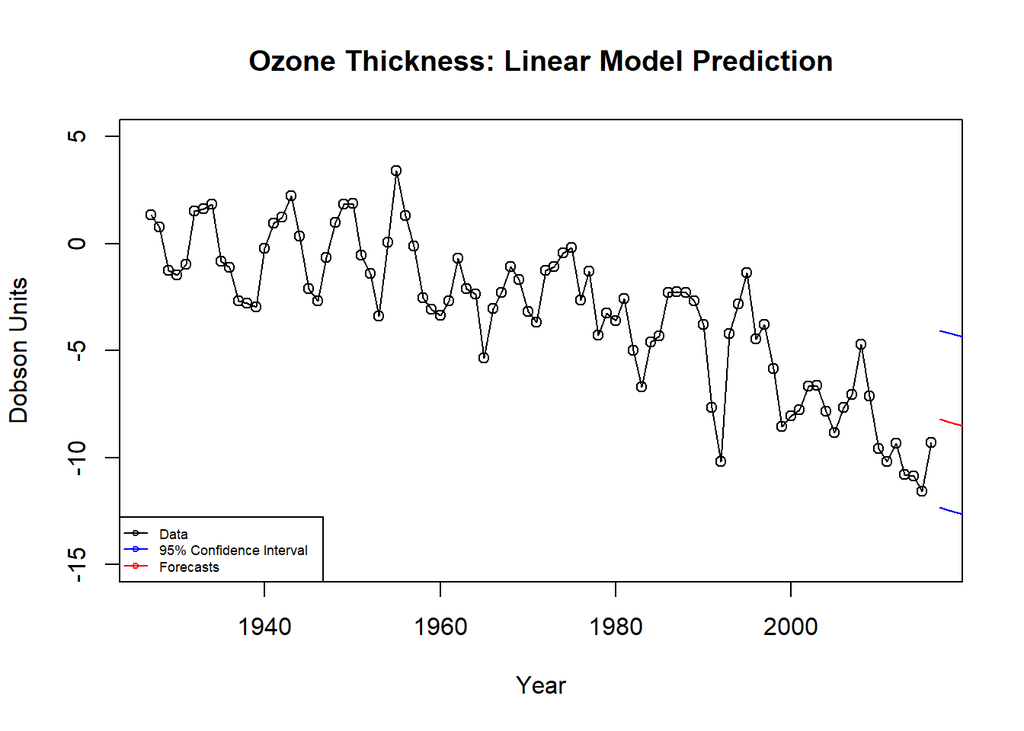

The forecast using the linear regression model appears higher than might be expected, given the values of the preceeding data points. As there was an apparent trend observed in the residuals of this model, an analysis of the quadratic regresson model may produce more satisfying forecast values.

## Quadratic Regression Model:

The following graph shows the data with the quadratic regression line included in red.

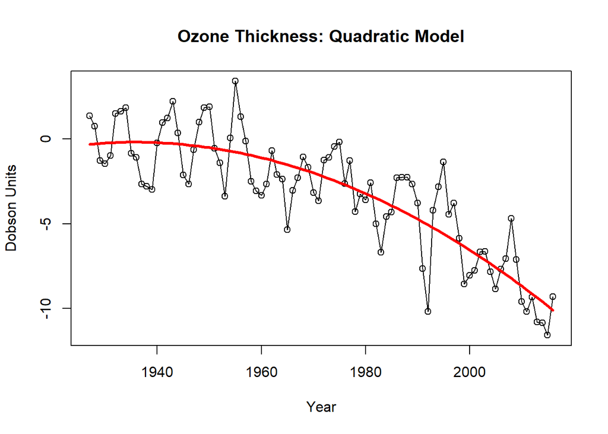

### Summary of Quadratic Model

```
##
## Call:
## lm(formula = ozone_ts ~ t + t2)
##
## Residuals:
##     Min      1Q  Median      3Q     Max
## -5.1062 -1.2846 -0.0055  1.3379  4.2325
##
## Coefficients:
##               Estimate Std. Error t value Pr(>|t|)
## (Intercept) -5.733e+03  1.232e+03  -4.654 1.16e-05 ***
## t            5.924e+00  1.250e+00   4.739 8.30e-06 ***
## t2          -1.530e-03  3.170e-04  -4.827 5.87e-06 ***
## ---
## Signif. codes:  0 '***' 0.001 '**' 0.01 '*' 0.05 '.' 0.1 ' ' 1
##
## Residual standard error: 1.815 on 87 degrees of freedom
## Multiple R-squared:  0.7391, Adjusted R-squared:  0.7331
## F-statistic: 123.3 on 2 and 87 DF,  p-value: < 2.2e-16
```

The data appears to be distributed more evenly on either side of the trend line than in the linear model. The p-value for the trend line is again significant, indicating that there is decent correlation. The R-squared value is 0.73, an improvement on the R-squared value of the linear trend line.

### Analysis of the Residuals of the Quadratic Regression Model

The plot of standardized residuals against time shows the points are more evenly distributed above and below the line at zero. The curve that appeared in this plot for the linear model has been removed.

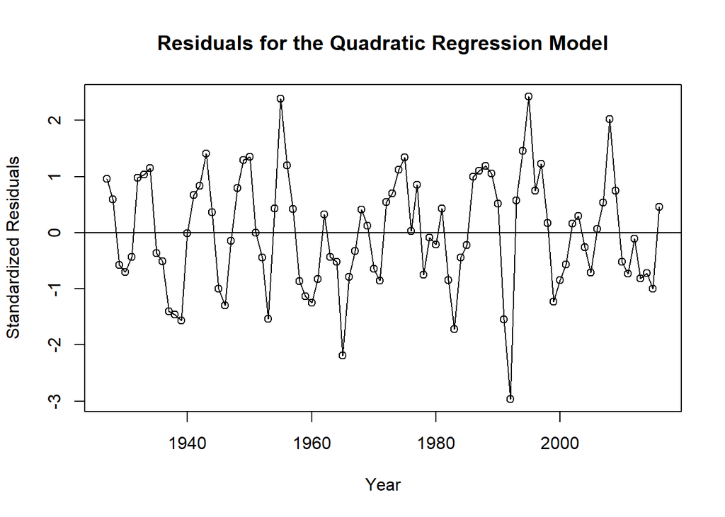

The Shapiro-Wilk normality test results:

```
##
##  Shapiro-Wilk normality test
##
## data:  res.model2
## W = 0.98889, p-value = 0.6493
```

The p-value is not significant so the null hypothesis is not rejected. The residuals behave as normally distributed data.

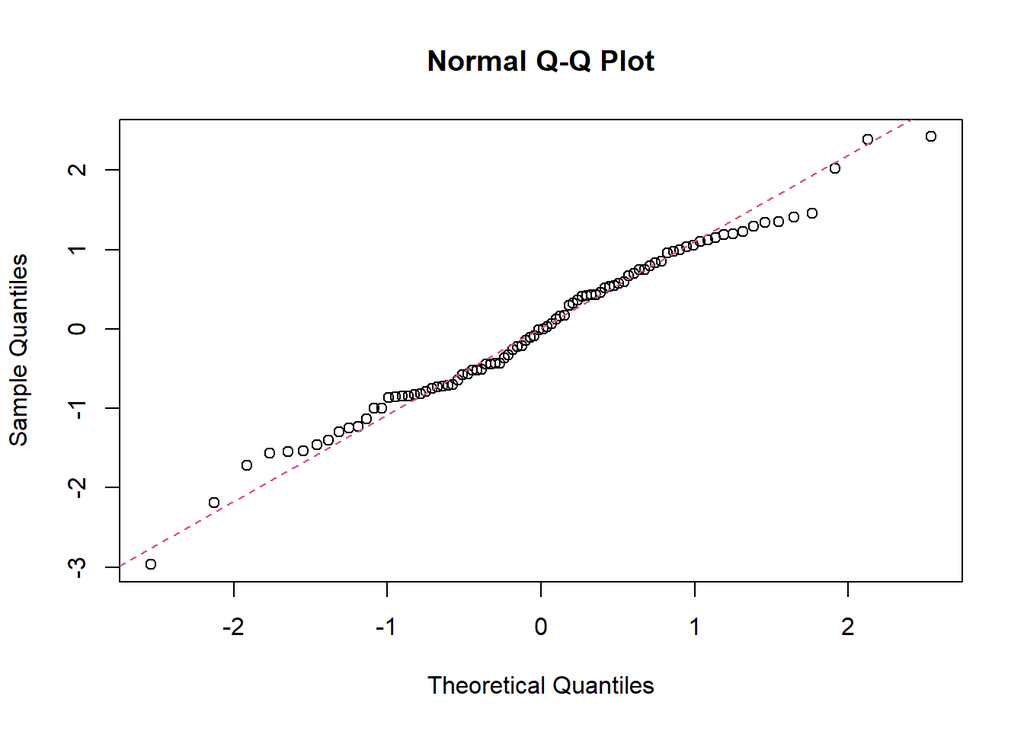

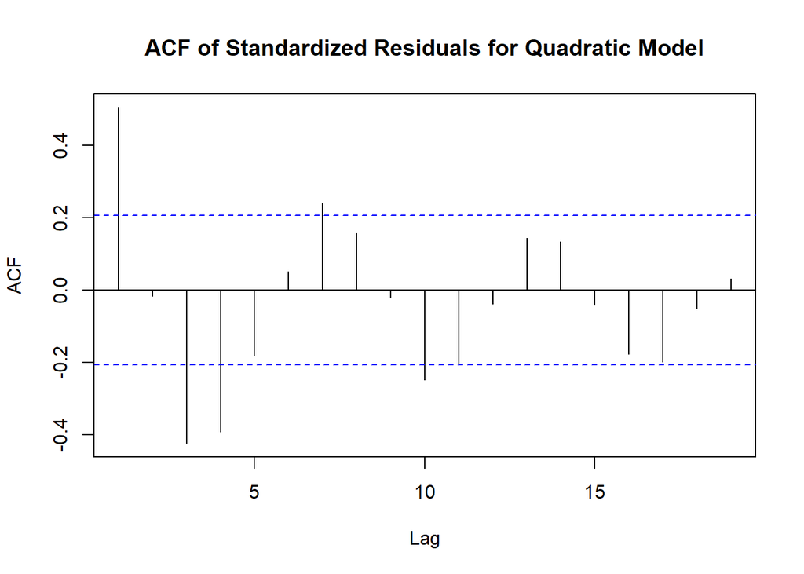

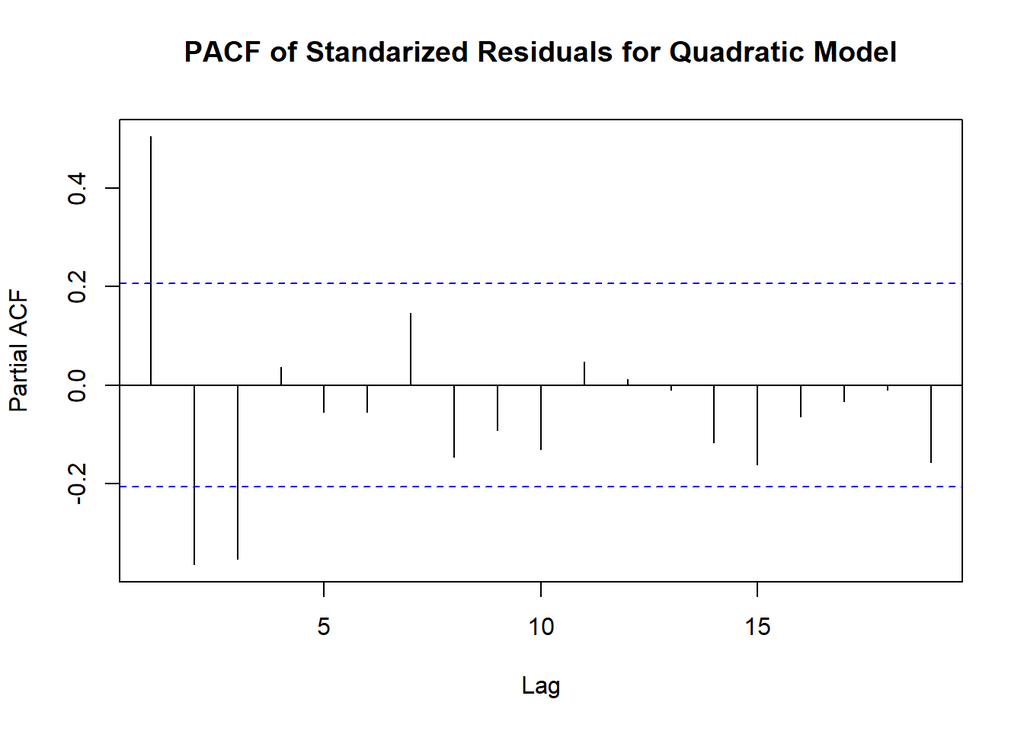

The QQ plot shows less departure from the reference line compared with the linear regresson model.

The ACF and PACF plots reveal that residuals do not appear strictly random. There appears to be correlation with lags 1, 3, and 4 in the ACF plot and correlation with lags 1, 2, and 3 in the PACF plot.

### Predictions of the Quadratic Regression Model

Predicting the next five data points using the quadratic model:

```
##      t
## 1 2017
## 2 2018
## 3 2019
## 4 2020
## 5 2021
```

```
##         fit       lwr       upr
## 1 -10.34387 -14.13556 -6.552180
## 2 -10.59469 -14.40282 -6.786548
## 3 -10.84856 -14.67434 -7.022786
## 4 -11.10550 -14.95015 -7.260851
## 5 -11.36550 -15.23030 -7.500701
```

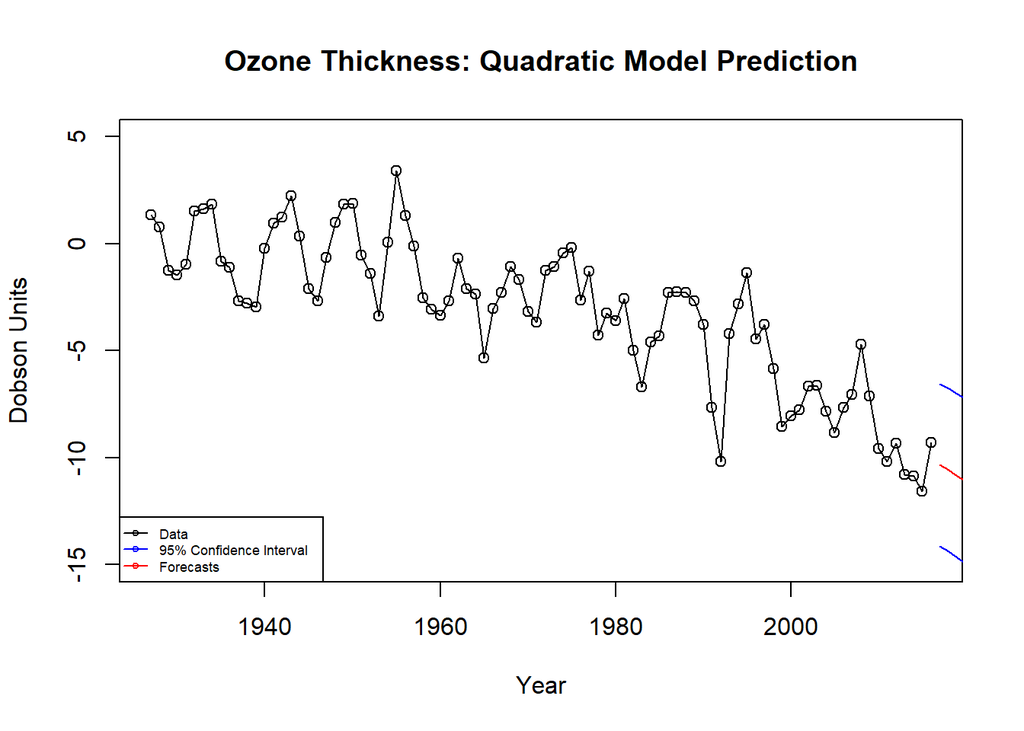

Visually, the predictions using the quadratic model appear to capture both the mean and variation of adjacent data points as well as the general downward trend more effectively than that of the linear model.

## Conclusion

The quadratic regression model appears to fit the ozone thickness data better than the linear model.

The Shapiro-Wilk test failed to reject the hypothesis that the residuals of either model were normally distributed. The QQ plots for the residuals of both models support this assumption.

The residuals for both models are not entirely random. Their respective PACF and ACF plots revealed correlation above the confidence bound at several lags. This indicates there may be a different type of model that is more appropriate for this dataset.

The major difference in the residual plots was that the linear model residuals exhibited curvature. No such trend appeared in the residuals for the quadratic model.

The R-squared values for the linear and quadratic models were 0.67 and 0.73 respectively. Though the quadratic model was an improvement, it is likely there is another type of model that fits the data more accurately.

The predictions of the quadratic model appear to give a mean and confidence interval that were more reflective of the data immediately preceeding it than the linear model. The downward trend exhibited in the predictions of the quadratic model were more pronounced than than the predications of the linear model.